# Potato Snacks Analysis - 김한범

**전체 개요**

1. 주제 선정 과정

   (1) 과자 시장 규모

   (2) 유형별 과자 비율

   (3) 감자과자 선정 및 이유

2. 데이터 수집 및 분석 개요

```
(1)  데이터 수집: 수집 대상, 수집 출처, 수집방법

(2)  분석 방법 및 개요
```

3. Text Mining - 빈도분석

```
(1) word cloud : 트위터 워드 클라우드와 네이버 블로그 워드 클라우드 비교

(2). word frequency : 단어들 빈도 분석
```

4. Text Mining - 상관분석

```
(1). 상관관계(network)

(2). Graphical Lasso
```

5. Text Mining - 연관규칙

```
(1). 연관규칙 생성

(2). 연관규칙 시각화
```

6. Time series analysis

```
(1). 검색어 분석

(2). 검색어 시계열 예측
```

7. Summary

# 1. Text Mining 주제 선정 과정

## 1 - (1) 우리 나라 스낵 과자 시장 규모

| year | sales |
| --- | --- |
| 2014년 | 12.289 |
| 2015년 | 13.510 |
| 2016년 | 12.270 |

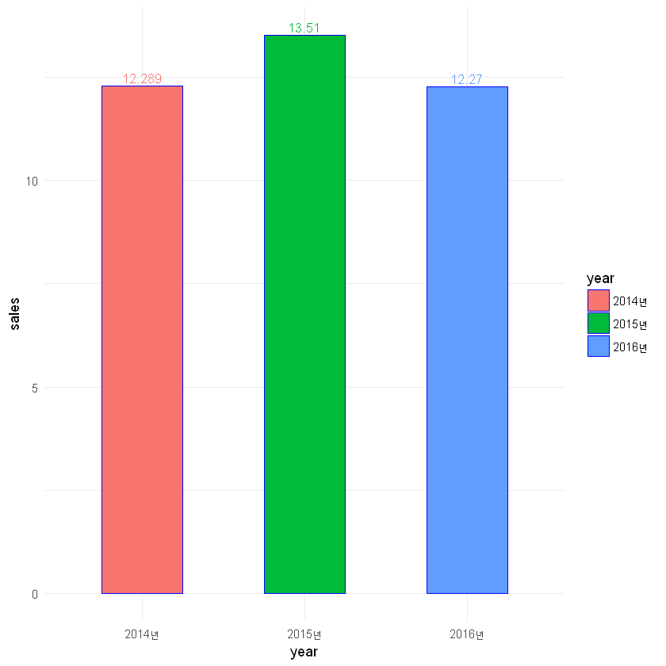

```r
snack_year <- data.frame(year=c("2014년", "2015년", "2016년"),
                sales=c(12.289, 13.510, 12.270))
head(snack_year)

bp<-ggplot(data=snack_year, aes(x=year, y=sales, width = 0.5, color = year, fill = year)) +
  geom_bar(stat="identity", color= 'blue')+
  geom_text(aes(label=sales), vjust=-0.3, size=3.5)+
    theme_minimal()
bp
```

**-> 스낵과자 소매시장은 2014년 1조 2,289억원에서 2015년 1조 3,510억원으로 9.9% 증가했으나, 2016년 9.2% 감소하며 다시 정체되는 양상을 보이고 있다.** </b>

- 식품 의약품 안전처에 의하면 과자류는 식물성원료 등을 주원료로 하여 다른 식품 또는 식품첨가물을 가하여 가공한 과자(비스킷류, 스낵과자류 등), 한과, 캔디(사탕,캐러멜, 양갱, 젤리 등), 추잉껌(무설탕껌, 일반추잉껌, 풍선껌), 빙과류를 말한다. 이 리포트에서는 과자류 중 가공한 과자에 속하는 스낵과자를 다룬다.

* 자료: 식품산업통계정보-www.atfix.or.kr

## 1 - (2) 국내 스낵 과자 시장 점유율

| group | value |
| --- | --- |
| 오리온 | 24.9 |
| 농심 | 32.3 |
| 해테 | 13.9 |
| 롯데 | 13.4 |
| 크라운 | 15.5 |

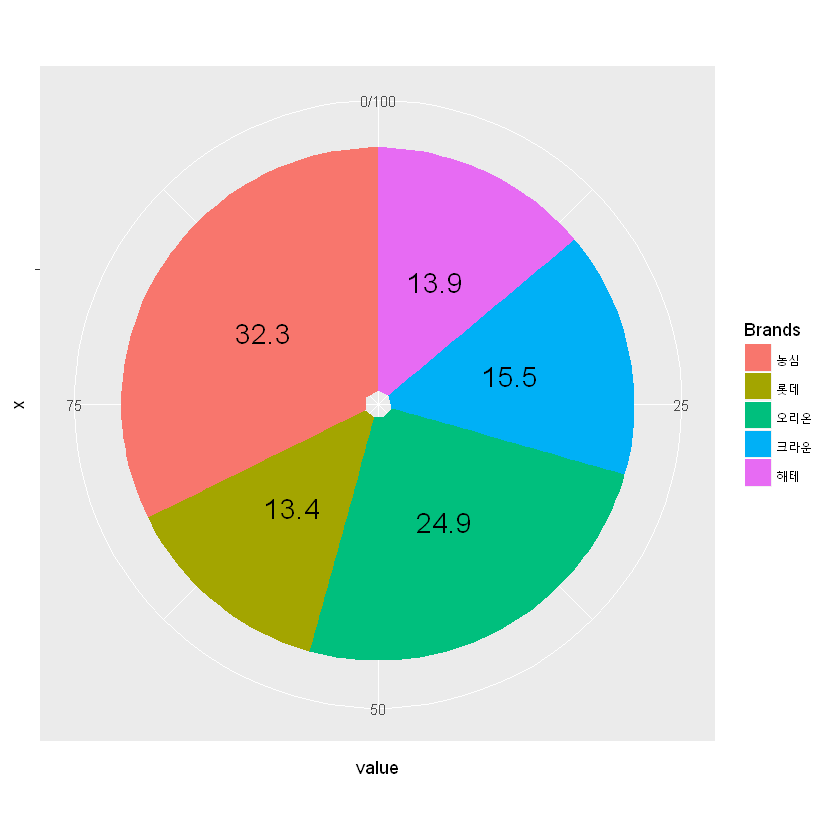

```r
snack_brand <- data.frame(
  group = c("오리온", "농심", "해테","롯데",'크라운'),
  value = c(24.9, 32.3, 13.9,13.4,15.5)
  )
head(snack_brand)

blank_theme <- theme_minimal()+
  theme(
  axis.title.x = element_blank(),
  axis.title.y = element_blank(),
  panel.border = element_blank(),
  panel.grid=element_blank(),
  axis.ticks = element_blank(),
  plot.title=element_text(size=14, face="bold")
  )


cp<- ggplot(snack_brand, aes(x='', y=value, fill=group))+
geom_bar(stat = "identity")+
coord_polar("y")+
geom_text(aes(label = value),position=position_stack(vjust=0.5), size=6)+
labs(fill='Brands')

cp
```

* 자료: AC 닐슨

## 1 - (3) 과자 매출 비교(주요 원료별)

| product | year | percentage |
| --- | --- | --- |
| 소맥 | 2015-04-01 | 31.3 |
| 소맥 | 2015-07-01 | 28.1 |
| 소맥 | 2015-10-01 | 29.0 |
| 소맥 | 2015-12-01 | 32.1 |
| 소맥 | 2016-04-01 | 34.2 |
| 소맥 | 2016-07-01 | 34.8 |

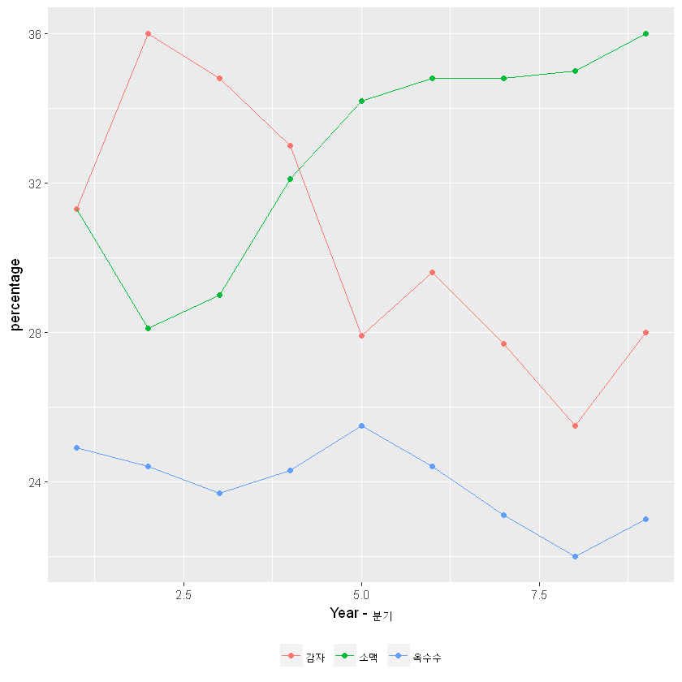

```r
snack_raw <- read.csv('C:/Users/hanbum/Desktop/Data/Visualization Task/snack/snack_raw.csv')
head(snack_raw)

g1 <- ggplot(aes(y = percentage, x = as.numeric(year), colour = product), size=2,
                           data = snack_raw, stat="identity") +
geom_point() +
geom_line()+ xlab('Year - 분기')+
theme(legend.position="bottom", legend.direction="horizontal", legend.title = element_blank())


g1
```

**-> 위 그래프는 2015년 1분기 부터 2017년 1분기까지, 총 9분기의 과자 원료별 Market Share을 시간 순대로 표현한 것이다**

-> 허니버터칩의 등장으로 매출 1위를 차지했던 감자과자는 인기가 사그라진 모습이다</big></b>

* 소맥과자는 밀을 원료로 한 과자를 뜻함(ex. 새우깡, 꿀꽈배기)

* 자료 : 식품산업통계정보(www.atfis.or.kr)

## 1 - (4) 주제 선정

-> 감자를 주원료로 하는 과자는 짭짤한 대중적인 맛과 다양한 양념에 잘 어울리기 떄문에, 일정한 수익을 보장해주는 제과업계의 효자 상품이다.

-> 2014년 하반기에 나온 허니버터칩 열풍은 감자 과자를 효자 상품군에서 주력 상품군으로 확장시켰다.

3년이 지난 현재에는 감자 과자의 매출은 허니버터칩 열풍 이전으로 돌아간 상태이다,

-> 그러나, 스낵 과자 시장의 전통의 강자인 감자 과자 시장의 패권을 차지하기 위해 각 업체들은 각기 다른 마케팅을 시도하는 중이다.

-> 따라서, 이 리포트에선 각 제과 업체별로 감자 과자의 주력상품들을 선정하여 **Text Analysis**를 통해 소비자들이 해당 감자 과자에 대해 어떻게 생각하는지를 분석하고자 한다.

-> 위와 같은 분석을 하기 위한 데이터는 네이버 블로그, 트위터, 페이스북 **Crawling**을 통해 모은다.

->여기에 더해, **시계열 분석**을 통해 해당 감자 과자 검색어 에측을 해보도록 한다.

선정한 과자들 = #오리온-포카칩 / 농심-수미칩 / 해테 - 허니버터칩 / 롯데 - 레이즈(lays) 감자칩, PB-이마트 노브랜드 감자칩

[figure not shown]

[figure not shown]

[figure not shown]

[figure not shown]

[figure not shown]

```r
display_png(file='C:/Users/hanbum/Desktop/Data/Visualization Task/snack/포카칩.png')
display_png(file='C:/Users/hanbum/Desktop/Data/Visualization Task/snack/수미칩.png')
display_png(file='C:/Users/hanbum/Desktop/Data/Visualization Task/snack/허니버터칩.png')
display_png(file='C:/Users/hanbum/Desktop/Data/Visualization Task/snack/레이즈.png')
display_png(file='C:/Users/hanbum/Desktop/Data/Visualization Task/snack/노브랜드감자칩.png')
```

# 2. Text Mining 데이터 수집 및 분석 개요

## 2 - (1) 데이터 수집

수집 대상 : 오리온-포카칩 / 농심-수미칩 / 해테 - 허니버터칩 / 롯데 - 레이즈 감자칩 / PB-이마트 노브랜드 감자칩

수집 방법 : R을 통한 크롤링

수집 출처 : 네이버 블로그, 트위터, 페이스북

## 2 - (1) - (i). 데이터 수집(네이버 블로그)

```r
#네이버 블로그 Text 수집
#네이버 API 아이디와 비밀번호

Sys.setlocale("LC_ALL", "Korean")
client_id = '5vYAgVwBHv7rgNU2l7Yv';
client_secret = 'WAqz45PQfV';
header = httr::add_headers('X-Naver-Client-Id' = client_id,
                           'X-Naver-Client-Secret' = client_secret)

# 검색할 단어와 encoding 변환

query.n =  query ='이마트 노브랜드 감자칩'
query = iconv(query, to = 'UTF-8', toRaw = T)
query = paste0('%', paste(unlist(query), collapse = '%'))
query = toupper(query)

# url 저장(여기선 블로그 url)
i = 1
end_num = 1000
display_num = 100
start_point = seq(1,end_num,display_num)

url = paste0('https://openapi.naver.com/v1/search/blog.xml?query=',query,'&display=',display_num,'&start=',start_point[i],'&sort=sim')
url_body = read_xml(GET(url, header))

# 텍스트 정보 추출
final_dat = NULL

for(i in 1:length(start_point))
{
  url = paste0('https://openapi.naver.com/v1/search/blog.xml?query=',query,'&display=',display_num,'&start=',start_point[i],'&sort=sim')
  url_body = read_xml(GET(url, header), encoding = "UTF-8")
  title = url_body %>% xml_nodes('item title') %>% xml_text()
  bloggername = url_body %>% xml_nodes('item bloggername') %>% xml_text()
  postdate = url_body %>% xml_nodes('postdate') %>% xml_text()
  link = url_body %>% xml_nodes('item link') %>% xml_text()
  description = url_body %>% html_nodes('item description') %>% html_text()
  temp_dat = cbind(title, bloggername, postdate, link, description)
  final_dat = rbind(final_dat, temp_dat)
  cat(i, '\n')
}

final_dat = data.frame(final_dat, stringsAsFactors = F)

head(final_dat)

# 형태소 분석을 위한 데이터 정제
dat_tmp <- final_dat
for (i in 1:nrow(final_dat))
{
  dat_tmp[i,5]<-   gsub(pattern = "<[/|A-Za-z]*>",
       replace = "", final_dat[i,5])
}
```

'LC_COLLATE=Korean_Korea.949;LC_CTYPE=Korean_Korea.949;LC_MONETARY=Korean_Korea.949;LC_NUMERIC=C;LC_TIME=Korean_Korea.949'

```
1
2
3
4
5
6
7
8
9
10
```

| title | bloggername | postdate | link | description |
| --- | --- | --- | --- | --- |
| <b>이마트 노브랜드 감자칩</b> | 먹고노는 이야기 | 20170913 | http://blog.naver.com/thro4321?Redirect=Log&logNo=221094853871 | <b>이마트 노브랜드 감자칩</b> 이마트 노브랜드 제품이 나오면서 저희집 식료품들이 많이 바뀐듯 합니다. 집안 이곳저곳 을 보다보면 아.. 나도 모르게 많이 바뀐게 많구나 해요.. 월요일 저녁 와이프하고 아들녀석이... |
| <b>이마트 노브랜드 감자칩</b> 오리지널 후기&amp; 영양성분 칼로리 | 이쿤의 봄여름가을겨울 | 20170813 | http://blog.naver.com/kun-lee?Redirect=Log&logNo=221072810113 | 단거좋아하시는분은 노브랜드 고구마칩을 더 좋아하더라구요~ <b>이마트 노브랜드 감자칩</b> 오리지널 후기 끗! 만약 이마트가 가까이 없다면 이마트몰을 이용하는것도 방법이에요~ &lt;이마트인터넷쇼핑몰 바로가기... |
| <b>이마트</b>24 <b>노브랜드 감자칩</b> 사워크림 &amp; 어니언 | Juny's Blog | 20170919 | http://blog.naver.com/hbj1646?Redirect=Log&logNo=221099994704 | <b>이마트</b>24 <b>노브랜드 감자칩</b> 사워크림 &amp; 어니언 후기개인적으로 <b>노브랜드</b>에서 나오는 제품 중 추천하는 스낵 중 하나입니다. <b>감자칩</b> 가격은 저렴한데 프링글스와 맛이 매우 비슷합니다. 짭짤하고 바삭한 맛... |
| <b>이마트 노브랜드 감자칩</b> 오리지널 &amp; 자색고구마칩 솔직한 리뷰! | party shadow | 20170818 | http://blog.naver.com/ysju94?Redirect=Log&logNo=221077098961 | <b>이마트 노브랜드 감자칩</b> 오리지널 &amp; 자색고구마칩 솔직한 리뷰! 이마트 노브랜드하면 감자칩 오리지널, 샤워크림 &amp; 자색고구마칩을 많이들 드시는데요. 최근에도 먹을정도로 애용하고 있는 노브랜드 감자칩... |
| <b>이마트 노브랜드 감자칩</b> 자색고구마칩 가격도 맛도 좋네요 | 술패랭이 | 20170606 | http://blog.naver.com/1030ysk?Redirect=Log&logNo=221022678731 | 일요일에 신랑과 <b>이마트</b>에 다녀왔어요. 사실 마트를 자주 가는 편은 아닌데 우리 신랑이 워낙 쇼핑을... <b>노브랜드 감자칩</b>과 자색고구마칩 애들이 좋아하는 같은 형태의 외국브랜드 <b>감자칩</b>은 너무 비싸요. 요건... |
| <b>이마트 노브랜드 감자칩</b> 사워크림&amp;어니언 | 좀좀이의 여행 | 20170328 | http://zomzom.tistory.com/2007 | 이번에 먹어본 과자는 <b>이마트 노브랜드 감자칩</b> 사워크림&amp;어니언이에요. 이 과자는 노브랜드 제품 중 꽤 인기가 많다고 알려진 제품이에요. 이 과자의 장점은 천원 채 안 된다는 점. 그렇다고 해서 질소... |

```r
#crawling data들을 csv파일로 저장해두자
write.table(posts,'poca_blog.csv',sep=',',row.names=F)
```

## 2 - (1) - (ii). 데이터 수집(트위터)

```r
#key확보 및 정상 작동 확인
consumer_key ='RI2MdUEhcKVBqSDDwzKjnlShQ'
consumer_secret ='l1Lf9W3X8QjcwYdSl9amVRNPllNfuQFfJCwsjNEClmIpnNyaEg'
access_token = '884200639504334848-XeH2JlMrufay8vUV9hQ4EwLhH0tz5M4'
access_secret = '1iX6m5a4y0wofmA1s9l1VROxF48NgtvxqxtllOxPYXD7Y'

setup_twitter_oauth(consumer_key,consumer_secret,access_token,access_secret)

#찾고자 하는 단어 입력, 3000개 트위터 검색
string <- '이마트 노브랜드 감자칩'
string <- iconv(string, 'CP949', 'UTF8')
tweets <- searchTwitter(searchString = string, n = 3000, lang="ko", retryOnRateLimit = 10000, )
head(tweets)

# 결과 중에서 텍스트에 해당하는 부분만 추출하고 확인
text_extracted <- sapply(tweets, function(t) t$getText())

#불필요한 문자들은 모두 제거
text_extracted <- gsub("\n", "", text_extracted)
text_extracted <- gsub("\r", "", text_extracted)
text_extracted <- gsub("RT", "", text_extracted)
text_extracted <- gsub("http", "", text_extracted)
text_extracted <- gsub("rt", "", text_extracted)
text_extracted <- gsub("ㅋㅋㅋㅋㅋㅋ", "", text_extracted)
text_extracted <- gsub("@\\w+", "", text_extracted) #user name
text_extracted <- gsub("[ |\t]{2,}", "", text_extracted) #remove tabs
text_extracted <- gsub("노브랜드", "", text_extracted)
text_extracted <- gsub("감자칩", "", text_extracted)
head(text_extracted)

# 문자 분리
result_nouns <- Map(extractNoun, text_extracted)
result_wordsvec <- unlist(result_nouns, use.name=F)
result_wordsvec <- result_wordsvec[-which(result_wordsvec %in% stopwords("english"))]
result_wordsvec <- gsub("[[:punct:]]","", result_wordsvec)
result_wordsvec <- Filter(function(x){nchar(x)>=2}, result_wordsvec)

head(result_wordsvec)
```

```
[1] "Using direct authentication"
```

```
[[1]]
[1] "owo_away: 어제 티지님 드린거: 후드티\n어제 짜누님 드린거: 자색고구마칩, 이마트 노브랜드 감자칩 8ㅅ8 그리고 이룸 모르는 저거 https://t.co/mXhLDgtM5e"

[[2]]
[1] "knyck1107: 오는길에 이마트 편의점 들러서 샐러드랑 노브랜드 감자칩 사왔는데 샐러드가 싱싱하니 가득 담겨있어서 기분이 좋다"

[[3]]
[1] "gyxp: 마트가니까 온리프라이스라고 누가봐도 이마트 노브랜드 베낀거 있던데 감자칩 개맛없다 ㄹㅇ루"
```

1. '어제 티지님 드린거: 후드티어제 짜누님 드린거: 자색고구마칩, 이마트 8ㅅ8 그리고 이룸 모르는 저거 s://t.co/mXhLDgtM5e'

2. '오는길에 이마트 편의점 들러서 샐러드랑 사왔는데 샐러드가 싱싱하니 가득 담겨있어서 기분이 좋다'

3. '마트가니까 온리프라이스라고 누가봐도 이마트 베낀거 있던데 개맛없다 ㄹㅇ루'

```r
#crawling data들을 csv파일로 저장해두자
write.table(posts,'emart_twitt.csv',sep=',',row.names=F)
```

## 2 - (1) - (iii). 데이터 수집(페이스북)

- 페이스북 데이터를 모으기 위해선 crawling할 주소와 기간이 필요하다. 주소는 각 과자 업체의 공식 페이지로 했고, 기간은 2015/01/1부터 현재까지로 설정하였다.

```r
# Facebook 데이터 수집

#토큰 받고 저장하기
fb_oauth=fbOAuth(app_id="1529704550421200", app_secret= "735347178fa297dd1c597f88585e2ee3", extended_permissions=FALSE)

#내 계정으로 확인
getUsers('me',token=fb_oauth)

start_date='2015/01/01'
end_date='2017/09/24'
scrape_days=seq(from=as.Date(start_date), to=as.Date(end_date), by='days')
posts=c()

for(scrape_day in scrape_days)
{
  daypost=c()
  tryCatch({daypost=getPage(page="onlyorion",
                            token=fb_oauth,
                            since=as.Date(scrape_day, origin="1970-01-01"),
                            until=as.Date(scrape_day, origin="1970-01-01")+1
                            )
            },
           error=function(e){}
           )
  posts= rbind(posts, daypost)
}
head(posts)
```

```
Copy and paste into Site URL on Facebook App Settings: http://localhost:1410/
When done, press any key to continue...
```

```
Waiting for authentication in browser...
Press Esc/Ctrl + C to abort
Please point your browser to the following url:
https://www.facebook.com/dialog/oauth?client_id=1529704550421200&scope=public_profile%20user_friends&redirect_uri=http%3A%2F%2Flocalhost%3A1410%2F&response_type=code&state=CXdhHlyd6E
Authentication complete.
Authentication successful.
```

| id | name | username | first_name | middle_name | last_name | gender | locale | likes | picture |
| --- | --- | --- | --- | --- | --- | --- | --- | --- | --- |
| 279212895911049 | Hanbum Kim | NA | NA | NA | NA | NA | NA | NA | NA |

```r
#crawling data들을 csv파일로 저장해두자
write.table(posts,'poca_facebook.csv',sep=',',row.names=F)
```

*페이스북 자료는 분석에 사용하지 못했다. 페이스북 자료를 crawling하는 연습 정도의 의미로 이 리포트에 실었다.

## 2. (2) 분석 개요

지금까지 Text Analysis를 위한 text 데이터를 네이버 블로그, 트위터, 페이스북 Crawling을 통해 모았다. 다음 장에서는 모은 데이터를 활용해 실제로 이 데이터가 어떤 의미를 가지고 있는 지 분석해 보자.

분석 방법과 절차는 아래와 같다.

3. Text Mining - 빈도분석

4. Text Mining - 상관분석

5. Text Mining - 연관규칙

6. Time series analysis - 시계열 분석

사용한 라이브러리 -

library_basic = c('dplyr', 'ggplot2','igraph')

library_crawling = c('rvest', 'httr','xml2','curl','twitteR','Rfacebook')

library_textM = c('KoNLP','tm','Matrix','wordcloud')

library_visual=c('qgraph','rgl','scales','IRdisplay','scales','RColorBrewer')

library_association=c('arules','arulesViz')

library_times=c('tseries','TTR','forecast')

# 3. Text Mining - 빈도분석

## 3- (1) Wordcloud 비교

1. 네이버 블로그와 트위터에서 모은 각 과자 데이터별로 wordcloud를 그려보고, 어떤 차이가 있는지 알아보자

```r
#데이터를 불러오자
dat_tmp<-read.csv('C:/Users/hanbum/Desktop/Data/Visualization Task/snack/sumi_blog.csv') #네이버 블로그 데이터
head(dat_tmp)
str(dat_tmp)

result_wordsvec<-read.csv('C:/Users/hanbum/Desktop/Data/Visualization Task/snack/sumi_twitt.csv') #트위터 데이터
head(result_wordsvec)
str(result_wordsvec)

# 사전을 불러오자
useSejongDic()

# tm package is based on Eng. Addition option is required
text = dat_tmp[,5]
cps = Corpus(VectorSource(text))
dtm = tm::DocumentTermMatrix(cps,
            control = list(tokenize = extractNoun,
                                      removeNumber = T,
                                      removePunctuation = T))
str(dtm)

# matrix class
rmat <- as.matrix(dtm)

# sparseMatrix
rmat <-spMatrix(dtm$nrow,dtm$ncol, i=dtm$i, j=dtm$j, x=dtm$v)
wcount<-colSums(rmat)
wname <- dtm$dimnames$Terms
wname <- repair_encoding(dtm$dimnames$Terms)
colnames(rmat)<- wname

sort.var <- sort(wcount,decreasing = T)[100]
idx <- !( grepl('수미칩', wname)| (wcount<=sort.var) )
wname.rel <- wname[idx]
wcount.rel <- wcount[idx]

pal <- brewer.pal(9, "Set2")
# twitter wordcloud
result_wordcount <- table(result_wordsvec)

pal <- brewer.pal(7, "Set1")
```

| title | bloggername | postdate | link | description |
| --- | --- | --- | --- | --- |
| <b>수미칩</b> 프라임 새로운 두께감과 맛 | 또군공간 | 20170807 | http://blog.naver.com/ddo_gun?Redirect=Log&logNo=221068329912 | 오늘은 수미칩 프라임에 대해서 포스팅을 하려합니다. 평소 감자 과자 중에서는 수미칩이 참 맛있다고 생각하는 사람 중 한 명인데, 이번에 수미칩 프라임이라고 나왔더라구요. 평소 수미칩과는 전혀 다른... |
| <b>수미칩</b> 허니머스타드맛 달콤해 | 피부 새로고침♥ 아우름클리닉 | 20170809 | http://blog.naver.com/jeon6367?Redirect=Log&logNo=221070392923 | 그 뒤로 너무 맛있어서 자주 즐겨먹고 있답니다ㅎㅎ 한때 허니버터칩 대체품으로 나온 것 같은데 호불호는 갈리겠지만 저는 수미칩이 더 맞더라고요ㅎㅎ 수미칩이 허니버터칩보다 몇백원 비싸지만 양도 많고... |
| <b>수미칩</b> 허니머스타드에 밀맥주 한잔 좋아요~ | 상크미의 해피월드 ★ | 20170619 | http://hanpost33.tistory.com/1198 | 좋아하는 수미칩과 제일 좋아하는 맥주 파울라너 후기를 남겨봐요 ㅎ 독일 바이에른 뮌헨의 대표적인 밀맥주 파울라너 헤페바이스 그리고 농심 수미칩 허니머스타드, 이건 허니버터칩이 인기몰이하면서 같이... |
| 커피 디저트 <b>수미칩</b> 아메리카노와 꿀조합 | 쌍오 | 20170324 | http://blog.naver.com/foren00n?Redirect=Log&logNo=220957445349 | 수미칩이 새로워졌어요 여러분 전에 알던 수미칩 아냐 브랜뉴사운 수미칩이 더 두꺼워져서 프라임으로 태어난거 다들 아시나요!? 평상시 커피디저트를 애타게 찾던 제가 이 수미칩 프라임을 맛보고... |
| <b>수미칩</b>프라임 초콜릿과 로이스감자칩 | 진군의 이런저런 이야기 | 20170516 | http://blog.naver.com/gkmovingon?Redirect=Log&logNo=221006609870 | 수미칩프라임 초콜릿이었습니다. 마트에서 보자마자 바로 카트에 담았습니다. 와이프님께서... 수미칩프라임 초콜릿으로 좋아하는거 먹는다는 기분이라도 느끼셨으면 좋겠네요. 자 뜯어보겠습니다. 과연... |
| <b>수미칩</b> 프라임 초코, 제 점수는요 ? | SLOWLY | 20170512 | http://blog.naver.com/slowly__?Redirect=Log&logNo=221004314650 | 수미칩 프라임 초코, 제 점수는요 ? 냥히랑 전화하는데 토이스토리 초콜릿얘기하다가 꼬북칩얘기하다가 수미칩은 도대체 어디있냐던 그녀. 내 눈앞에 있는데요 ? 그래서 샀다. 로이스감자칩을 떠올리며 ! ( 힝... |

```
'data.frame':	834 obs. of  5 variables:
 $ title      : Factor w/ 793 levels "'<b>수미칩</b>' 프라임.. 감자칩의 격을 높이다!",..: 177 347 356 629 382 178 444 29 457 183 ...
 $ bloggername: Factor w/ 790 levels "-블로그쟁이가 된 조대리",..: 354 746 477 529 671 195 725 135 260 265 ...
 $ postdate   : Factor w/ 325 levels " <b>수미칩</b> 프라임 시식후기,치노의 래빗하우스,20170715,http://itboxtis.tistory.com/2019,편의점에 가니 수미칩"| __truncated__,..: 318 319 313 279 302 300 301 312 295 282 ...
 $ link       : Factor w/ 834 levels " <b>수미칩</b> 허니머스타드 비교 ( +꿀꽈배기),예그리나 chocolatier♡,20150624,http://blog.naver.com/fonti_?Redi"| __truncated__,..: 168 332 802 227 245 640 152 823 401 154 ...
 $ description: Factor w/ 834 levels "","' 수미칩 허니버터칩 ' 음 크기는 굉장히 컸어요 ! ㅋㅋㅋㅋ 기대감도 커졌지요 .. 생감자가 91% 들어가고, 용량은 저"| __truncated__,..: 574 131 664 512 514 380 670 699 638 572 ...
```

| x |
| --- |
| 프로 |
| 술꾼 |
| 칩수미백술도 |
| ㅋㅋㅋㅋㅋ |
| 옛날 |
| 별명이네요보고 |

```
'data.frame':	235 obs. of  1 variable:
 $ x: Factor w/ 203 levels "攼㹤愼㸰戼㹤攼㹤戼㸴愼㹢攼㹤愼㸰<"| __truncated__,..: 189 104 169 172 130 75 171 47 161 12 ...
Backup was just finished!
370957 words dictionary was built.
List of 6
 $ i       : int [1:17714] 1 1 1 1 1 1 1 1 1 1 ...
 $ j       : int [1:17714] 1 2 3 4 5 6 7 8 9 10 ...
 $ v       : num [1:17714] 1 1 1 1 1 1 1 1 1 2 ...
 $ nrow    : int 834
 $ ncol    : int 8171
 $ dimnames:List of 2
  ..$ Docs : chr [1:834] "1" "2" "3" "4" ...
  ..$ Terms: chr [1:8171] "감자" "과자" "나왔더라구요" "다른" ...
 - attr(*, "class")= chr [1:2] "DocumentTermMatrix" "simple_triplet_matrix"
 - attr(*, "weighting")= chr [1:2] "term frequency" "tf"
```

[output not shown]

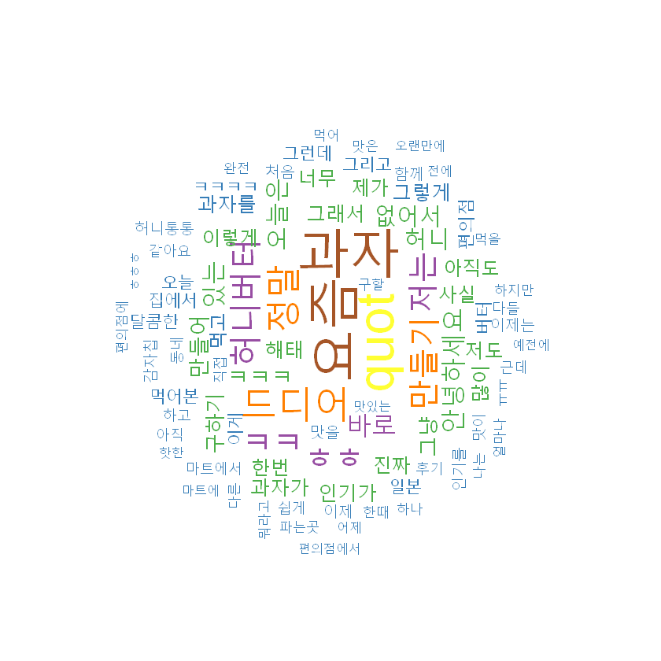

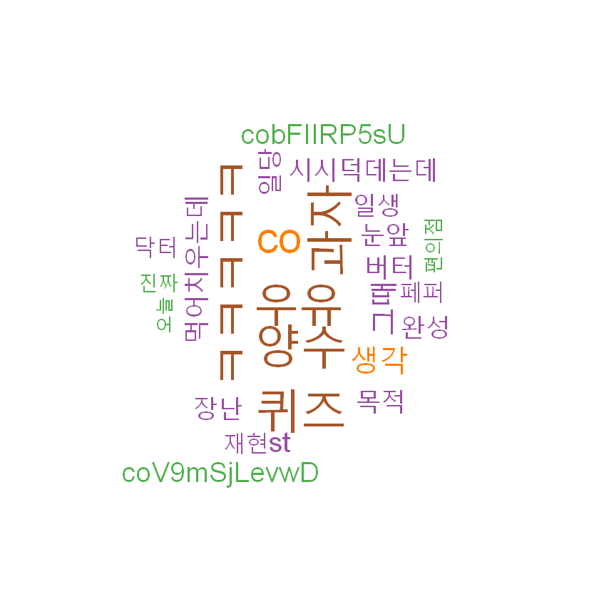

```r
# 허니버터칩 wordcloud

wordcloud(wname.rel, freq = wcount.rel,rot.per=0.35,random.order=FALSE,colors = pal)
wordcloud(names(result_wordcount), freq=result_wordcount,
          scale=c(4,0.5), min.freq=12, random.order=F, rot.per=0.35,
          colors=pal, family="malgun")
```

* 허니버터칩 wordcloud 비교

--네이버 블로그 : '만들다'는 단어와 '편의점', '드디어', '오늘'이란 단어가 많이 보인다

비교 : 허니버터칩과 편의점은 공통 분모를 가지고 있는 것으로 보인다

[output not shown]

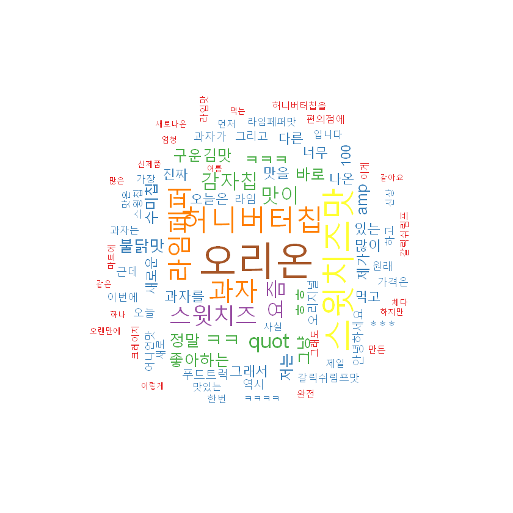

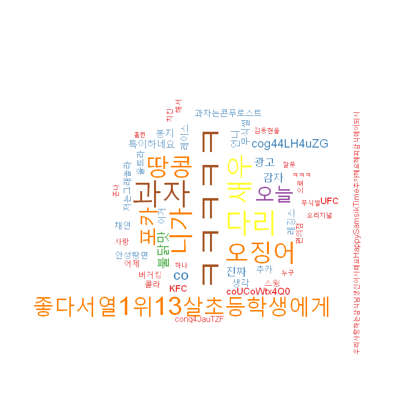

```r
# 포카칩 wordcloud

wordcloud(wname.rel, freq = wcount.rel,rot.per=0.35,random.order=FALSE,colors = pal)
wordcloud(names(result_wordcount), freq=result_wordcount,
          scale=c(4,0.5), min.freq=12, random.order=F, rot.per=0.35,
          colors=pal, family="malgun")
```

* 포카칩 wordcloud 비교

--네이버 블로그 : '맛과 관련된 검색어가 많이 보인다.(스윗치즈, 구운김맛,불닭맛 등등), 이외에도 다른 감자칩도 연관검색어로 많이 보인다.(수미칩,허니버터칩) 허니버터칩과는 달리 제조업체인 '오리온'이 연관 단어로 보인다는 것도 확인할 수 있다

-- 트위터 : 역시 맛과 관련된 검색어가 보이고, 단어 정제가 잘 안되어서 제대로 관계를 확인하기는 어려워 보인다.

비교 :포카칩은 맛과 관련된 단어가 많은 비중을 차지한다. 포카칩이 다양한 맛을 출시하기 때문인걸로 보인다

[output not shown]

[output cut: 72 more lines]

[output not shown]

[figure not shown]

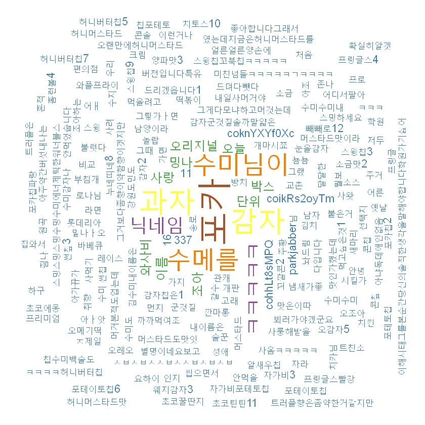

```r
# 수미칩 wordcloud

wordcloud(wname.rel, freq = wcount.rel,rot.per=0.35,random.order=FALSE,colors = pal)
wordcloud(names(result_wordcount), freq=result_wordcount,
          scale=c(4,0.5), min.freq=12, random.order=F, rot.per=0.35,
          colors=pal, family="malgun")
```

* 수미칩 wordcloud 비교

--네이버 블로그 : 수미칩의 연관 단어로 가장 많이 보이는 건 '허니'관련된 단어들이다. 수미칩의 히트 제품인 허니머스타드 맛 떄문인 걸로 보인다. 제조업체인 '농심'이 보이지만 포카칩의 오리온 만큼 연관성이 크게 나타나진 않아 보인다.

-- 트위터 : 맛과 관련된 단어들도 보이고, 다른 과자들(포카칩, 꼬깔콘)도 보인다.

비교 :수미칩의 데이터가 포카칩이나 허니버터칩보다 더 많은 정보량을 담고 있는 것으로 보이는데, 그 이유는 아마도 수미칩이 상대적으로 최근에 나온(허니버터칩의 대항마) 감자 과자 제품이기 떄문에, 인터넷을 자주 하는 세대들에게 더 어필 할 수 있었던 것으로 보인다

## 3- (2) Word Frequency 비교

트위터 데이터가 없는 레이즈 감자칩과 이마트 노브랜드 감자칩은 wordcloud 대신 barplot으로 어떤 단어가 가장 많이 관련되어서 나왔는지를 확인하자.

```r
#데이터를 불러오자
dat_tmp<-read.csv('C:/Users/hanbum/Desktop/Data/Visualization Task/snack/emart_blog.csv') #네이버 블로그 데이터

# 사전을 불러오자
useSejongDic()

# tm package is based on Eng. Addition option is required
text = dat_tmp[,5]
cps = Corpus(VectorSource(text))
dtm = tm::DocumentTermMatrix(cps,
            control = list(tokenize = extractNoun,
                                      removeNumber = T,
                                      removePunctuation = T))

# matrix class
rmat <- as.matrix(dtm)

rmat <-spMatrix(dtm$nrow,dtm$ncol, i=dtm$i, j=dtm$j, x=dtm$v)
wcount<-colSums(rmat)
wname <- dtm$dimnames$Terms
wname <- repair_encoding(dtm$dimnames$Terms)
colnames(rmat)<- wname

sort.var <- sort(wcount,decreasing = T)[100]
idx <- !( grepl('감자칩', wname)| (wcount<=sort.var) )
wname.rel <- wname[idx]
wcount.rel <- wcount[idx]
wcount<-sort(wcount.rel,decreasing = T)[1:20]
wname<-wname.rel[1:20]

dfcount <-data.frame(wcount,wname)
```

```
Backup was just finished!
370957 words dictionary was built.
```

[output not shown]

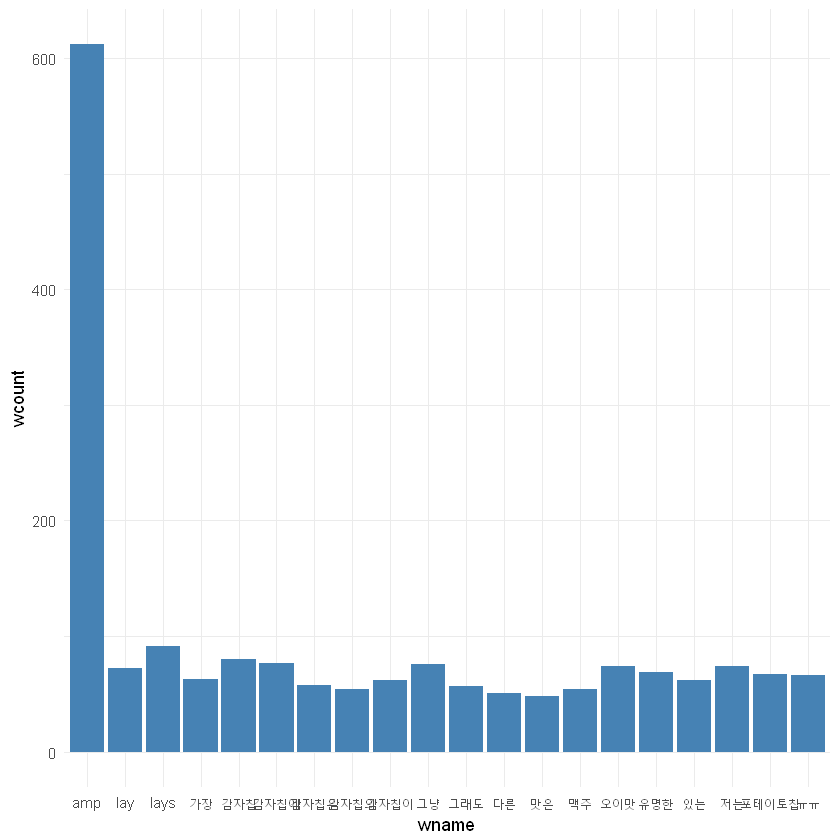

```r
p<-ggplot(data=dfcount, aes(x=wname, y=wcount)) +
  geom_bar(stat="identity", fill="steelblue")+
  theme_minimal()
p
```

* 레이즈 감자칩 word freqeuncy 결과

--네이버 블로그 : amp란 단어가 가장 많이 나오는데, 이는 레이즈 감자칩과는 관련 없는 단어로 보인다. '오이맛'은 레이즈 감자칩이 갖고 있는 독특한 맛종류이고, '유명한'이란 연관단어는 해외에서 더 유명한 제품이어서 연관검색어로 나온듯하다.

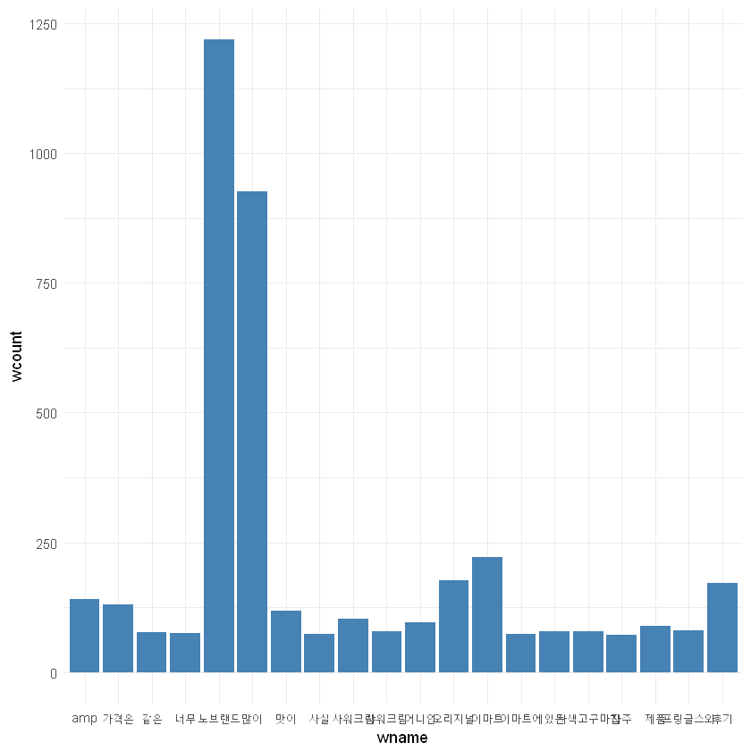

```r
p<-ggplot(data=dfcount, aes(x=wname, y=wcount)) +
  geom_bar(stat="identity", fill="steelblue")+
  theme_minimal()
p
```

* 이마트 노브랜드 감자칩 word freqeuncy 결과

--네이버 블로그 : '가격', '많이' 등은 노브랜드 (pb)제품의 특징을 보여주는 연관단어이다. 가성비를 중시하는 현재의 분위기를 잘 보여주는 연관단어이다.

# 4. Text Mining - 상관분석

## 4- (1) 상관관계 단어들 비교

단어들간의 상관관계를 확인해보고, 높은 순서대로 정렬해보자

```r
#데이터를 불러오자
dat_tmp<-read.csv('C:/Users/hanbum/Desktop/Data/Visualization Task/snack/sumi_blog.csv') #네이버 블로그 데이터
text = dat_tmp[,5]
cps = Corpus(VectorSource(text))
dtm = tm::DocumentTermMatrix(cps,
            control = list(tokenize = extractNoun,
                                      removeNumber = T,
                                      removePunctuation = T))
# matrix class
rmat <- as.matrix(dtm)

# 빈도수 확인
bb <- rmat
bb.freq <- sort(colSums(bb), decreasing = T)

# 빈도수가 많은 단어 필터링
bb.freq <- bb.freq[bb.freq>quantile(bb.freq,0.99)]
idx <- match(names(bb.freq),  colnames(bb))
bb.r <- bb[,idx]
bb.r <- as.matrix(bb.r)
cor.mat <- cor(bb.r)

# 상관관계순으로 1~10개만 추려내었다.
sort_word <- sort(cor.mat[1,], decreasing = T)[1:10]
```

**허니버터칩**

1

**만들기**

0.298050661256059

**파는곳**

0.142234369723456

**다들**

0.103672526808325

**집에서**

0.098578939124114

**정말**

0.0810811406884686

**핫한**

0.0777915019778848

**없어서**

0.0587105802246496

**오늘**

0.055566681918312

**요즘**

0.0547436750012508

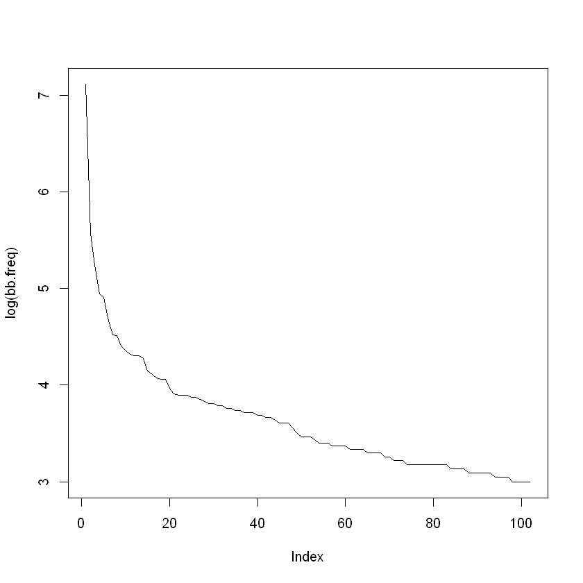

```r
#허니버터칩 빈도수와 상관관계
plot(log(bb.freq), pch = 19, type = 'l')
sort_word
```

**포카칩**

1

**스윗치즈**

0.159883153756516

**스윗치즈맛**

0.152157392573614

**불닭맛**

0.13759750918275

**신상**

0.130119574955866

**갈릭쉬림프맛**

0.113584063722749

**수미칩**

0.11199878475608

**오리온**

0.111074139989042

**라임페퍼맛**

0.110116641749004

**신제품**

0.107395764837995

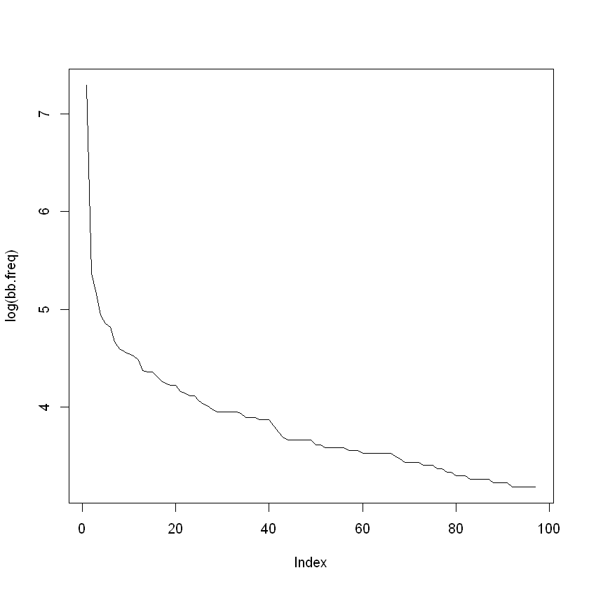

```r
#포카칩 빈도수와 상관관계
plot(log(bb.freq), pch = 19, type = 'l')
sort_word
```

**허니머스타드**

0.574626600535823

**허니버터칩**

0.444823628750596

**감자칩**

0.355463781139011

**포카칩**

0.340963341567472

**허니머스타드를**

0.328562906264164

**허니머스터드**

0.294376793681439

**농심**

0.281354061293965

**이게**

0.264352496422562

**정말**

0.237841576195453

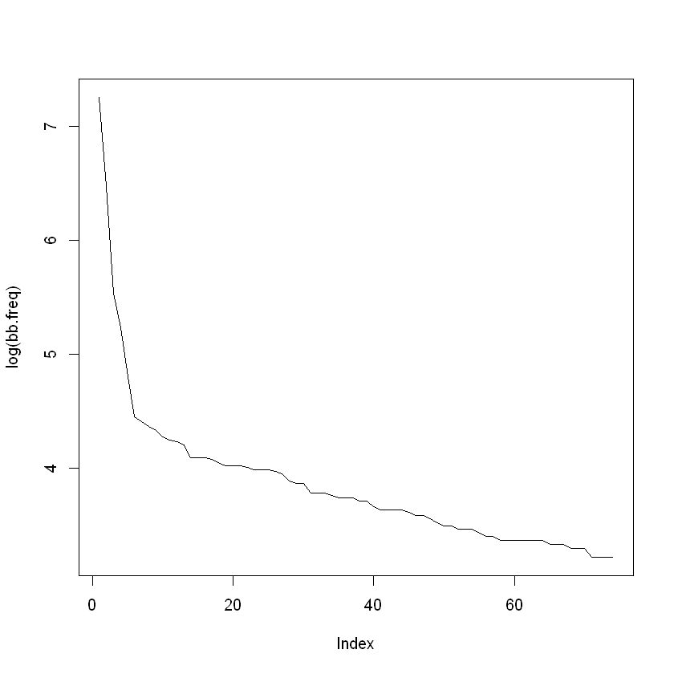

```r
#수미칩 빈도수와 상관관계
plot(log(bb.freq), pch = 19, type = 'l')

# 수미칩과 연관있는 단어들을 상관관계 순으로 정렬하면 1~8개는 모두 http, blog, com 등 연관 없는 단어들이다.
#따라서 9등부터 보았다.

sort_word <- sort(cor.mat[1,], decreasing = T)[9:17]
sort_word
```

* 허니버터칩, 포카칩, 수미칩의 단어들 상관관게 분석 결과

--허니버터칩 : '만들기', '집에서'라는 단어와의 상관관계가 높은 것으로 나타났다. 집에서 만들어 먹을 수 있는 허니버터칩 레시피 같은 것이 있는 것으로 생각한다.

--포카칩 : '스윗치즈', '붉닭맛', '신상'같은 단어와의 상관관계가 높은 것으로 나타났다. 포카칩의 판매전략은 새로운 맛을 출시하여 소비자들의 관심을 끄는 것인 것 같다.

--수미칩 : '허니머스타드' 맛이 화제인 것을 알 수 있고, 포카칩과의 상관관계도 높은 것으로 보아 두 제품간에는 대체제 관계가 성립될 것 같다.

* 레이즈 감자칩과, 이마트 노브랜드 감자칩 데이터는 network graph를 그려보자</font>

```r
#데이터를 불러오자
dat_tmp<-read.csv('C:/Users/hanbum/Desktop/Data/Visualization Task/snack/emart_blog.csv') #네이버 블로그 데이터
text = dat_tmp[,5]
cps = Corpus(VectorSource(text))
dtm = tm::DocumentTermMatrix(cps,
            control = list(tokenize = extractNoun,
                                      removeNumber = T,
                                      removePunctuation = T))
# matrix class
rmat <- as.matrix(dtm)

# 빈도수 확인
bb <- rmat
bb.freq <- sort(colSums(bb), decreasing = T)

# 빈도수가 많은 단어 필터링
bb.freq <- bb.freq[bb.freq>quantile(bb.freq,0.99)]
idx <- match(names(bb.freq),  colnames(bb))
bb.r <- bb[,idx]
bb.r <- as.matrix(bb.r)
```

```r
#bb.t matrix를 graph로 그릴 수 있게  작업이 필요하다. 우선 Boolean 로 바꿔 주자
bb.r <-t(bb.r)
bb.r[bb.r>=1] <- 1

# term-term adjacency matrix로 변환해보자
bb.t <- bb.r %*% t(bb.r )

#변환된 matrix를 확인해보자
head(bb.t)

#20개만 뽑아보자
bb.t<-bb.t[1:20,1:20]
```

|  | 노브랜드 | 이마트 | 감자칩 | amp | 어니언 | 오리지널 | 사워크림 | 요즘 | 이마트에서 | 과자 | ... | 눈에 | 유명한 | 추천 | 자주 | 저렴하고 | 이마트노브랜드 | 하지만 | 초콜릿 | 가장 | 입니다 |
| --- | --- | --- | --- | --- | --- | --- | --- | --- | --- | --- | --- | --- | --- | --- | --- | --- | --- | --- | --- | --- | --- |
| 노브랜드 | 847 | 633 | 590 | 179 | 151 | 133 | 111 | 107 | 101 | 74 | ... | 23 | 23 | 22 | 24 | 20 | 9 | 20 | 19 | 21 | 23 |
| 이마트 | 633 | 712 | 499 | 152 | 122 | 120 | 83 | 95 | 38 | 67 | ... | 17 | 17 | 20 | 21 | 21 | 7 | 17 | 16 | 21 | 20 |
| 감자칩 | 590 | 499 | 662 | 162 | 141 | 133 | 100 | 86 | 77 | 69 | ... | 15 | 21 | 18 | 13 | 13 | 11 | 11 | 12 | 17 | 16 |
| amp | 179 | 152 | 162 | 197 | 143 | 37 | 111 | 18 | 19 | 15 | ... | 4 | 5 | 3 | 4 | 4 | 3 | 5 | 3 | 4 | 8 |
| 어니언 | 151 | 122 | 141 | 143 | 166 | 29 | 92 | 15 | 15 | 13 | ... | 3 | 3 | 4 | 2 | 4 | 3 | 3 | 1 | 4 | 8 |
| 오리지널 | 133 | 120 | 133 | 37 | 29 | 152 | 18 | 23 | 14 | 23 | ... | 1 | 3 | 5 | 0 | 2 | 4 | 4 | 1 | 4 | 8 |

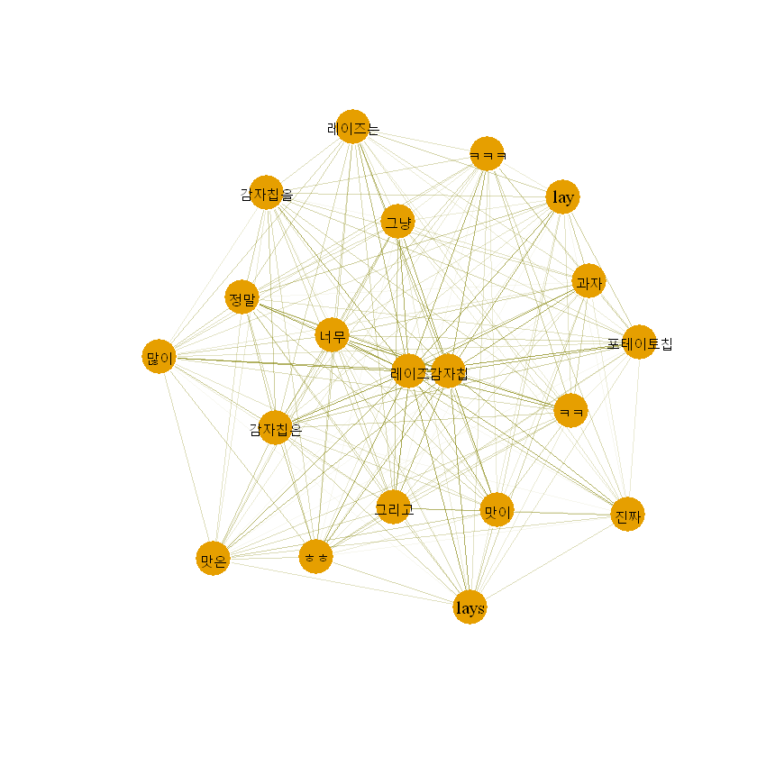

```r
g <- graph.adjacency(bb.t, weighted=T, mode='undirected')

# loops를 없앤다
g <- simplify(g)

V(g)$label.cex <- 2.2 * V(g)$degree / max(V(g)$degree)+ .2
V(g)$label.color <- rgb(0, 0, .2, .8)
V(g)$frame.color <- NA
egam <- (log(E(g)$weight)+.4) / max(log(E(g)$weight)+.4)
E(g)$color <- rgb(.5, .5, 0, egam)
E(g)$width <- egam

plot(g, layout=layout1,vertex.label.color="black")
```

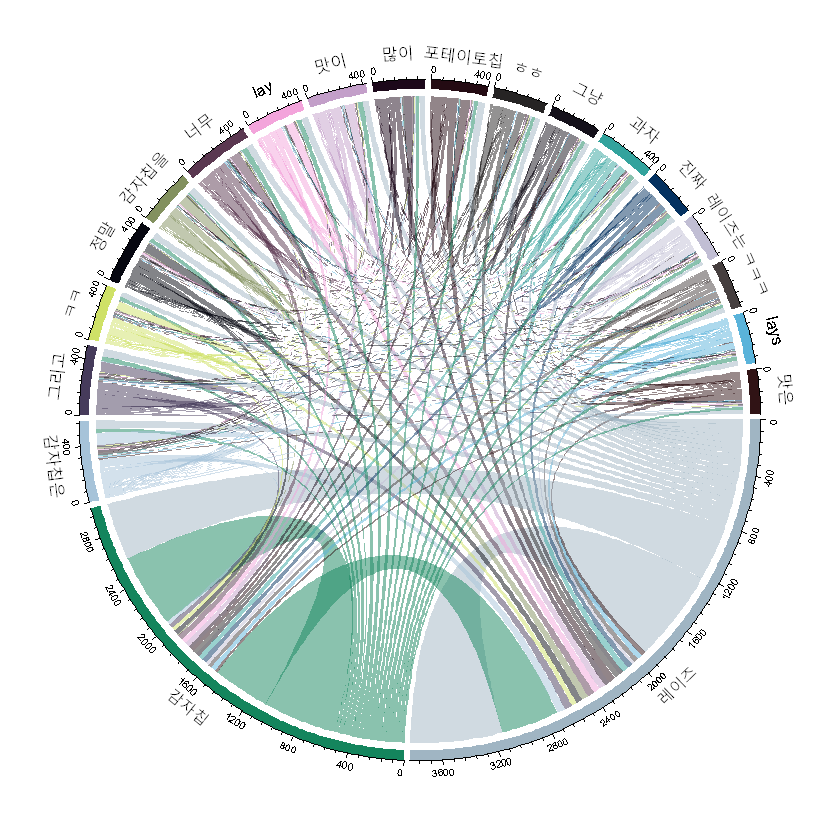

```r
chordDiagram(bb.t, transparency = 0.5)
```

- 레이즈 감자칩 : 의미있는 결과를 해석하기가 어렵다. 그래프는 예쁘지만, 유용한 결과를 얻기엔 어려워 보인다.

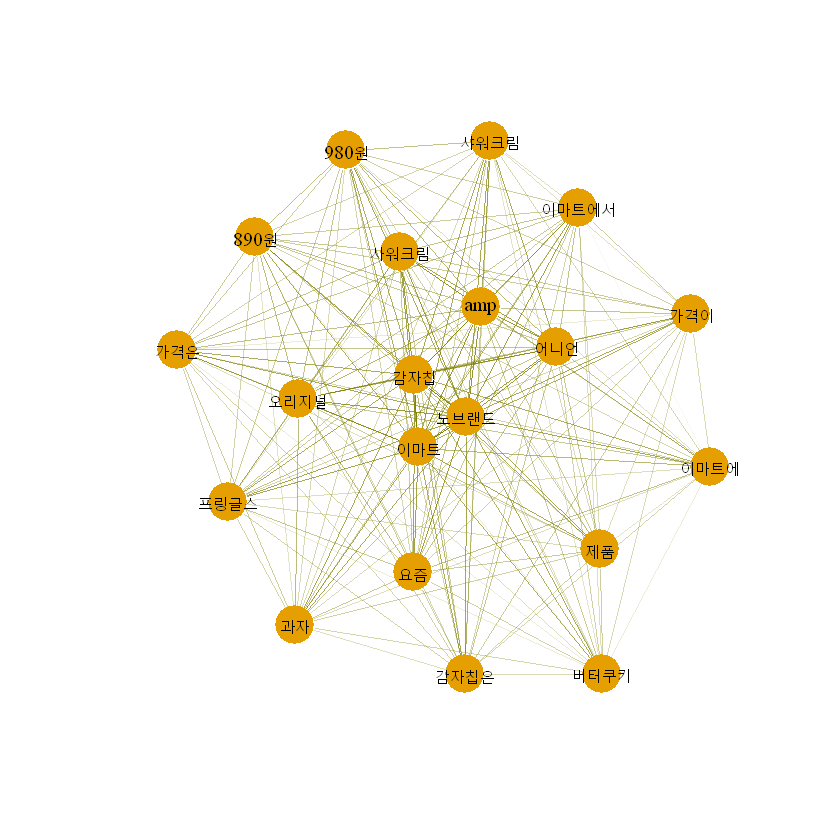

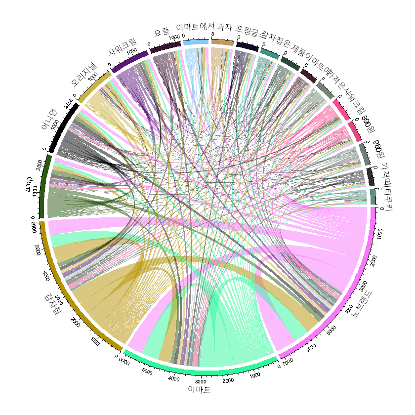

```r
g <- graph.adjacency(bb.t, weighted=T, mode='undirected')

# loops를 없앤다
g <- simplify(g)

V(g)$label.cex <- 2.2 * V(g)$degree / max(V(g)$degree)+ .2
V(g)$label.color <- rgb(0, 0, .2, .8)
V(g)$frame.color <- NA
egam <- (log(E(g)$weight)+.4) / max(log(E(g)$weight)+.4)
E(g)$color <- rgb(.5, .5, 0, egam)
E(g)$width <- egam

plot(g,vertex.label.color="black")
chordDiagram(bb.t, transparency = 0.5)
```

- 이마트 노브랜드 감자칩 : 그래프에서 '가격'이란 단어의 비중이 작은 것은 예상과는 다른 결과였다.위와 마찬가지로 그래프가 예쁘지만, 해석하기는 어렵다.

## 4- (2) Graphical Lasso 단어 상관관계 분석

단어들간의 상관 관계를 보기 위해 추가 변수의 효과를 제어하는 동시에 두 변수간 선형 관계를 설명하는 Partial correlation을 활용한다.

```r
#데이터를 불러오자
dat_tmp<-read.csv('C:/Users/hanbum/Desktop/Data/Visualization Task/snack/lays_blog.csv') #네이버 블로그 데이터
text = dat_tmp[,5]
cps = Corpus(VectorSource(text))
dtm = tm::DocumentTermMatrix(cps,
            control = list(tokenize = extractNoun,
                                      removeNumber = T,
                                      removePunctuation = T))
# matrix class
rmat <- as.matrix(dtm)

# 빈도수 확인
bb <- rmat
bb.freq <- sort(colSums(bb), decreasing = T)

# 빈도수가 많은 단어 필터링
bb.freq <- bb.freq[bb.freq>quantile(bb.freq,0.99)]
idx <- match(names(bb.freq),  colnames(bb))
bb.r <- bb[,idx]
bb.r <- as.matrix(bb.r)

cor.mat <- cor_auto(bb.r,detectOrdinal = FALSE)
```

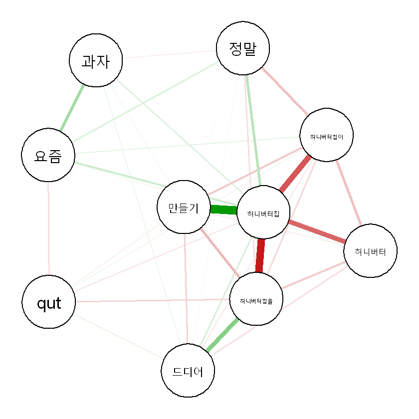

```r
# 허니버터칩 glasso 그래프를 그려 보자
qgraph(cor.mat[1:10,1:10], method='glasso',
       vsize=12, maximum=.05, border.width=2,layout = "spring")
```

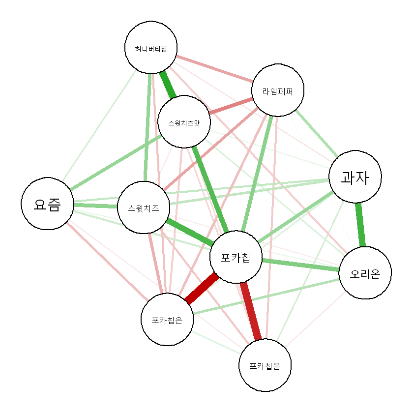

```r
# 포카칩 glasso 그래프를 그려 보자
qgraph(cor.mat[1:10,1:10], method='glasso',
       vsize=12, maximum=.05, border.width=2,layout = "spring")
```

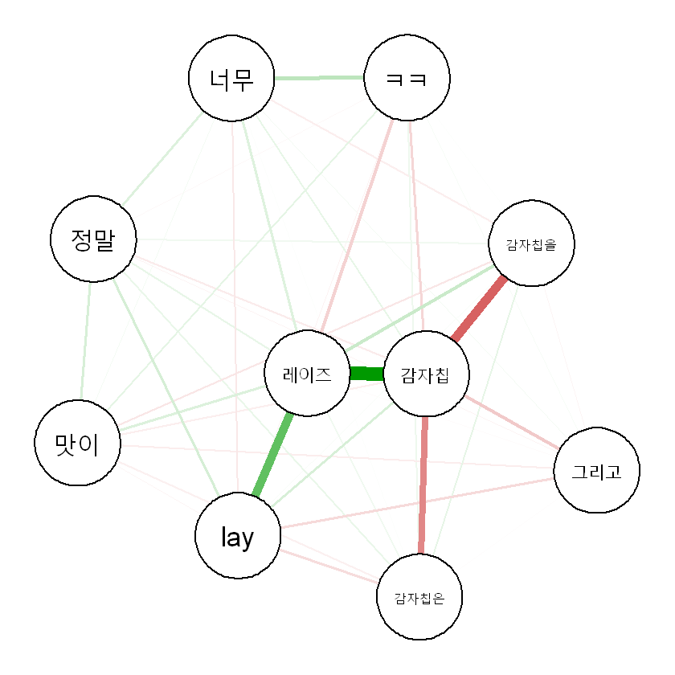

```r
# 레이즈 감자칩 glasso 그래프를 그려 보자
qgraph(cor.mat[1:10,1:10], method='glasso',
       vsize=12, maximum=.05, border.width=2,layout = "spring")
```

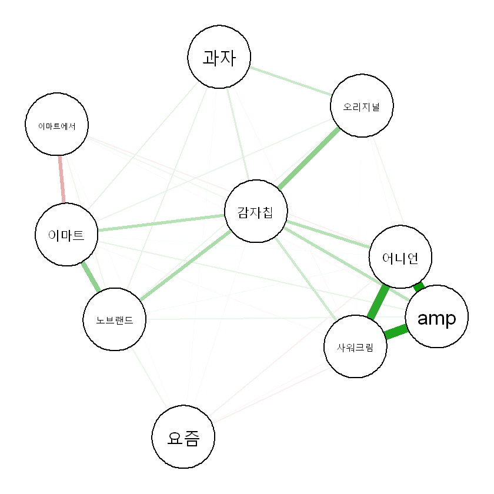

```r
# 이마트 노브랜드 감자칩 glasso 그래프를 그려 보자
qgraph(cor.mat[1:10,1:10], method='glasso',
       vsize=12, maximum=.05, border.width=2,layout = "spring")
```

* Glasso summary

- 상관계수가 높았던 단어들이 graphical lasso 그래프에서도 많이 보이지만, partial correlation을 활용하였기에 단어들 사이의 link가 끊어진 것을 확인 할 수 있다

# 5. Text Mining - 연관규칙

*사용한 데이터는 네이버 블로그에서 모은 허니버터칩과 포카칩이다.

## 5- (1) 연관규칙 생성

```r
#데이터를 불러오자
dat_tmp<-read.csv('C:/Users/hanbum/Desktop/Data/Visualization Task/snack/poca_blog.csv') #네이버 블로그 데이터
text = dat_tmp[,5]
cps = Corpus(VectorSource(text))
dtm = tm::DocumentTermMatrix(cps,
            control = list(tokenize = extractNoun,
                                      removeNumber = T,
                                      removePunctuation = T))
# matrix class
rmat <- as.matrix(dtm)

# 빈도수 확인
bb <- rmat
bb.freq <- sort(colSums(bb), decreasing = T)

# 빈도수가 많은 단어 필터링
bb.freq <- bb.freq[bb.freq>quantile(bb.freq,0.99)]
idx <- match(names(bb.freq),  colnames(bb))
bb.r <- bb[,idx]
bb.tt<-bb.r[1:20,1:20]
bb.df<-as.data.frame(as.table(bb.tt))

#연관규칙생성을 위한 transaction class 변환
snack.list<-split(bb.df$Terms, bb.df$Freq)
snack.transaction<-as(snack.list, "transactions")
snack.transaction
```

```
transactions in sparse format with
 5 transactions (rows) and
 20 items (columns)
```

```r
#허니버터칩 연관규칙 생성
rules = apriori(snack.transaction, parameter=list(support=0.001, confidence=0.6))
summary(rules)
```

[output not shown]

```
 done [0.65s].
writing ... [5188164 rule(s)] done [2.92s].
creating S4 object  ... done [7.33s].
```

```
set of 5188164 rules

rule length distribution (lhs + rhs):sizes
      1       2       3       4       5       6       7       8       9      10
      4     280    2874   17378   72515  223551  530628  995748 1502631 1842555

   Min. 1st Qu.  Median    Mean 3rd Qu.    Max.
  1.000   8.000   9.000   8.753  10.000  10.000

summary of quality measures:
    support         confidence          lift            count
 Min.   :0.2500   Min.   :0.6667   Min.   :0.8889   Min.   :1.00
 1st Qu.:0.2500   1st Qu.:1.0000   1st Qu.:2.0000   1st Qu.:1.00
 Median :0.2500   Median :1.0000   Median :2.0000   Median :1.00
 Mean   :0.2525   Mean   :1.0000   Mean   :2.5347   Mean   :1.01
 3rd Qu.:0.2500   3rd Qu.:1.0000   3rd Qu.:4.0000   3rd Qu.:1.00
 Max.   :1.0000   Max.   :1.0000   Max.   :4.0000   Max.   :4.00

mining info:
              data ntransactions support confidence
 snack.transaction             4   0.001        0.6
```

```r
#포카칩 연관규칙 생성
rules = apriori(snack.transaction, parameter=list(support=0.001, confidence=0.6))
summary(rules)
```

```
Apriori

Parameter specification:
 confidence minval smax arem  aval originalSupport maxtime support minlen
        0.6    0.1    1 none FALSE            TRUE       5   0.001      1
 maxlen target   ext
     10  rules FALSE

Algorithmic control:
 filter tree heap memopt load sort verbose
    0.1 TRUE TRUE  FALSE TRUE    2    TRUE

Absolute minimum support count: 0

set item appearances ...[0 item(s)] done [0.00s].
set transactions ...[20 item(s), 5 transaction(s)] done [0.00s].
sorting and recoding items ... [20 item(s)] done [0.00s].
creating transaction tree ... done [0.00s].
checking subsets of size 1 2 3 4 5 6 7 8 9 10
```

```
 done [0.59s].
writing ... [5239676 rule(s)] done [2.58s].
creating S4 object  ... done [7.49s].
```

```
set of 5239676 rules

rule length distribution (lhs + rhs):sizes
      1       2       3       4       5       6       7       8       9      10
      3     265    3039   18661   76664  231888  542304 1007664 1511628 1847560

   Min. 1st Qu.  Median    Mean 3rd Qu.    Max.
   1.00    8.00    9.00    8.74   10.00   10.00

summary of quality measures:
    support      confidence       lift           count
 Min.   :0.2   Min.   :0.6   Min.   :1.000   Min.   :1
 1st Qu.:0.2   1st Qu.:1.0   1st Qu.:2.500   1st Qu.:1
 Median :0.2   Median :1.0   Median :5.000   Median :1
 Mean   :0.2   Mean   :1.0   Mean   :3.716   Mean   :1
 3rd Qu.:0.2   3rd Qu.:1.0   3rd Qu.:5.000   3rd Qu.:1
 Max.   :1.0   Max.   :1.0   Max.   :5.000   Max.   :5

mining info:
              data ntransactions support confidence
 snack.transaction             5   0.001        0.6
```

## 5- (2) 연관규칙 시각화

- 위에서 구한 연관규칙을 시각화하여 표현해보자

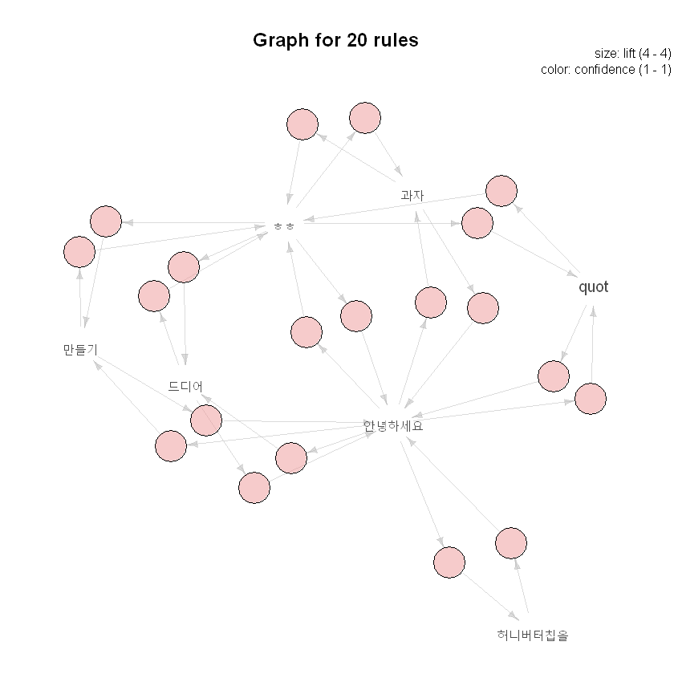

```r
# 허니버터칩 연관규칙 시각화
subrules <- head(sort(rules, by="lift"), 20)
plot(subrules, method="graph",measure = 'lift',shading = 'confidence')
```

- 허니버터칩 연관규칙 : 과자와 관련된 단어보다 블로그에서 흔히 볼 수 있는 인사말이 많이 나온것으로 보아 단어 정제 과정이 더 필요했던 것 같다.

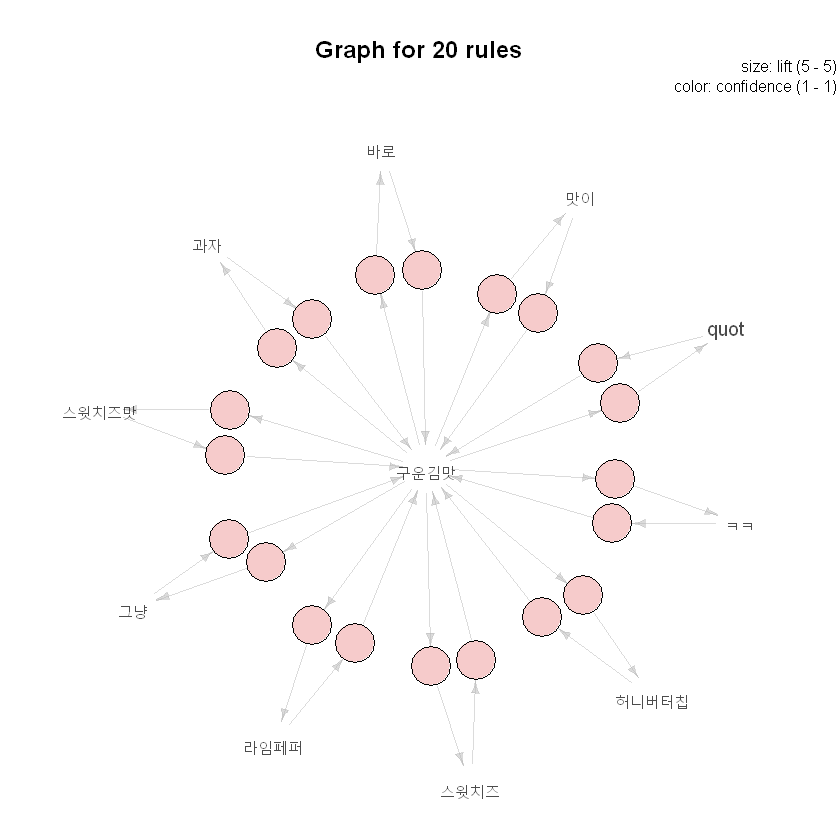

```r
# 포카칩 연관규칙 시각화
subrules <- head(sort(rules, by="lift"), 20)
plot(subrules, method="graph",measure = 'lift',shading = 'confidence')
```

- 포카칩 연관규칙 : 맛을 중심으로 관계가 형성되어 있다.

# 6. Time Series Analysis

- 검색어를 바탕으로 시계열 분석을 해보자
- 사용한 데이터는 네이버 블로그에서 모은 허니버터칩, 이마트 노브랜드 감자칩이다.

## 6- (1) 일일 검색어 분석

```r
#데이터를 불러오자
dat_tmp<-read.csv('C:/Users/hanbum/Desktop/Data/Visualization Task/snack/emart_blog.csv') #네이버 블로그 데이터
text = dat_tmp[,5]
cps = Corpus(VectorSource(text))
dtm = tm::DocumentTermMatrix(cps,
            control = list(tokenize = extractNoun,
                                      removeNumber = T,
                                      removePunctuation = T))
# matrix class
rmat <- as.matrix(dtm)

# 빈도수 확인
bb <- rmat
bb.freq <- sort(colSums(bb), decreasing = T)

# 빈도수가 많은 단어 필터링
bb.freq <- bb.freq[bb.freq>quantile(bb.freq,0.99)]
idx <- match(names(bb.freq),  colnames(bb))
bb.r <- bb[,idx]

# top posting blogger and link
tb <- table(dat_tmp[,2])
top.blogger<- sort(tb, decreasing = T)[1:4]
tmp <- dat_tmp %>% select(bloggername, link) %>%
filter(bloggername %in% names(top.blogger) )

#post date Analysis(문자열을 날짜로 변환하기 위한 작업)
tb <- table(dat_tmp$postdate)
x <-as.Date(names(tb), format = "%Y%m%d")
y <- as.numeric(tb)

xx <- as.Date(as.integer(min(x)):as.integer(max(x)),
        origin = "1970-01-01")
yy <- rep(0, length(xx))
yy[xx%in%x] <-y

xint <- as.integer(xx)
rdata = data.frame(y = yy, x = xint)
fit<-loess(y~x,data = rdata, span = 0.1, normalize = FALSE)

# 모형 복잡도 선택
k.fold = 5
set.seed(1)
idx <-sample(1:k.fold, length(xint), replace = TRUE)
k = 1
rdata.tr <- rdata[idx != k, ]
rdata.va <- rdata[idx == k, ]

valid.err <- c()
span.var <- seq(0.02, 0.5, by  = 0.01)
valid.mat <- NULL

for (j in 1:length(span.var))
{
  valid.err <- c()
  for (k in 1:k.fold)
  {
    rdata.tr <- rdata[idx != k, ]
    rdata.va <- rdata[idx == k, ]
    fit<-loess(y~x,data = rdata.tr,
               span = span.var[j], normalize = FALSE)
    fit.y<-predict(fit, newdata = rdata.va)
    valid.err[k] <- mean((fit.y-rdata.va$y)^2, na.rm = T)
 }
      valid.mat <- cbind(valid.mat, valid.err)
}

# model decision
span.par<- span.var[which.min(colMeans(valid.mat))]
fit<-loess(y~x,data = rdata,
           span = span.par, normalize = FALSE)
```

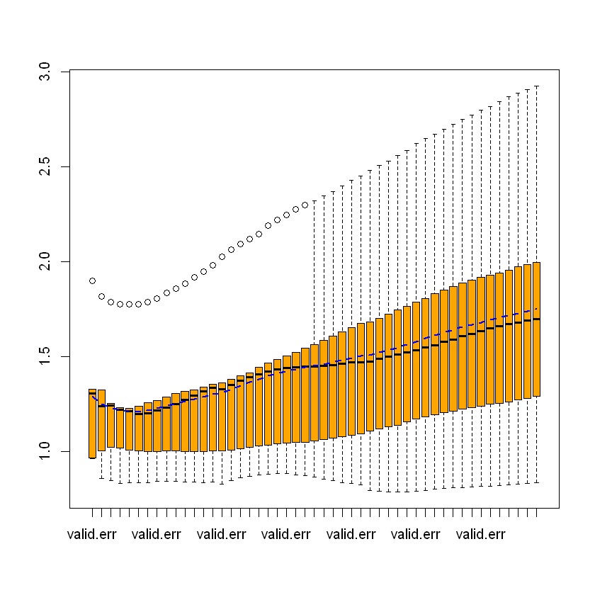

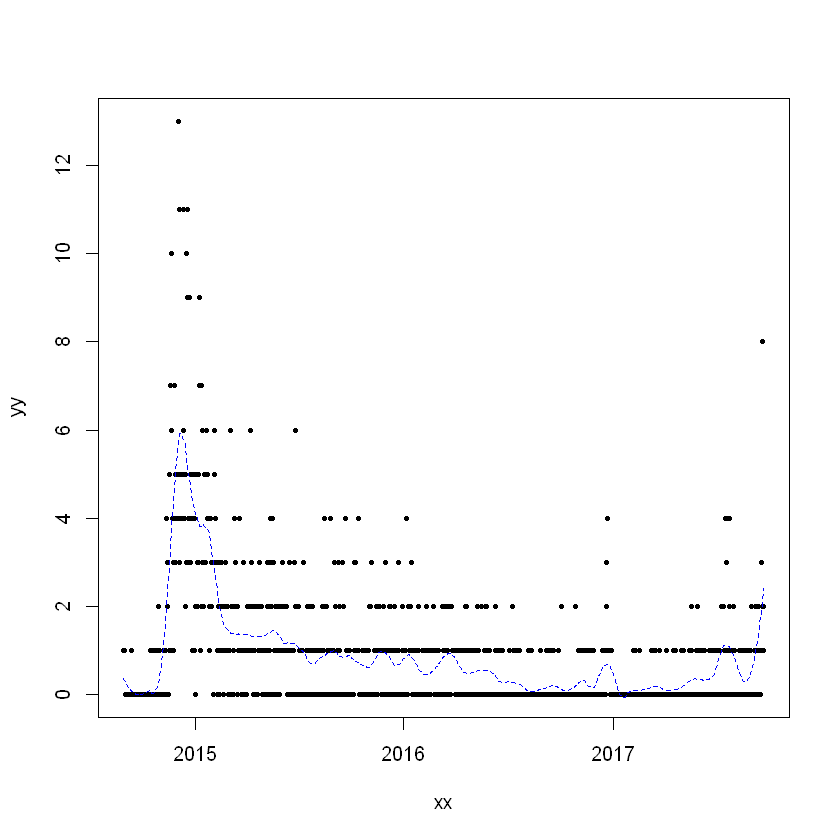

```r
#허니버터칩 검색어
boxplot(valid.mat, col='orange')
lines(colMeans(valid.mat), col = "blue", lty = 2, lwd = 2)

plot(xx,yy,  pch = 19, cex = 0.5)
points(xx,fit$fitted, type = 'l', lty = 2, lwd = 1.5, col = 'blue')
```

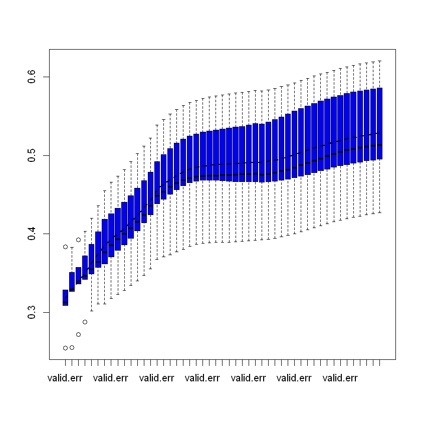

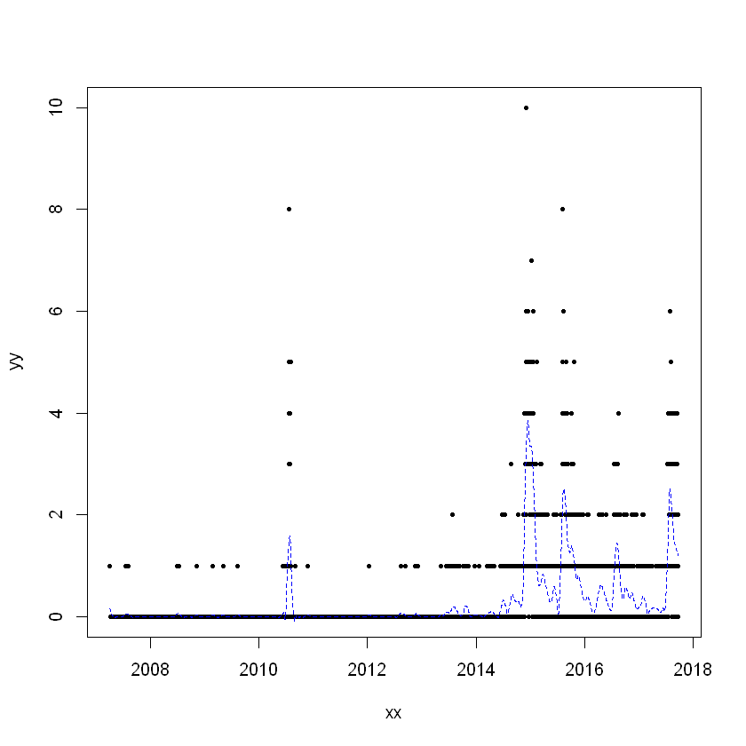

```r
#포카칩 검색어
boxplot(valid.mat, col='blue')
lines(colMeans(valid.mat), col = "black", lty = 2, lwd = 2)

plot(xx,yy,  pch = 19, cex = 0.5)
points(xx,fit$fitted, type = 'l', lty = 2, lwd = 1.5, col = 'blue')
```

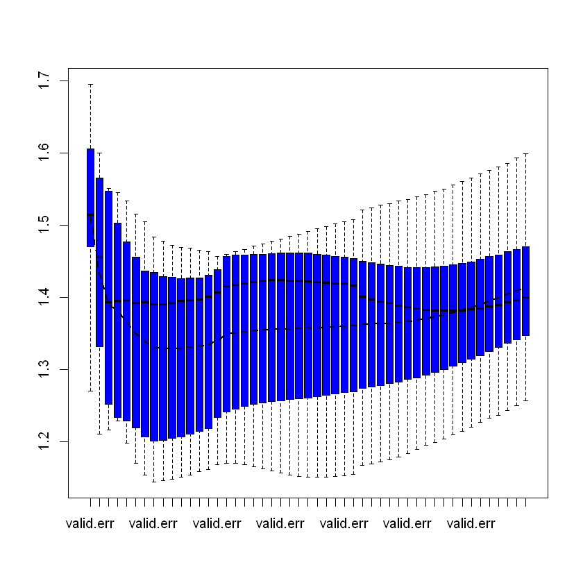

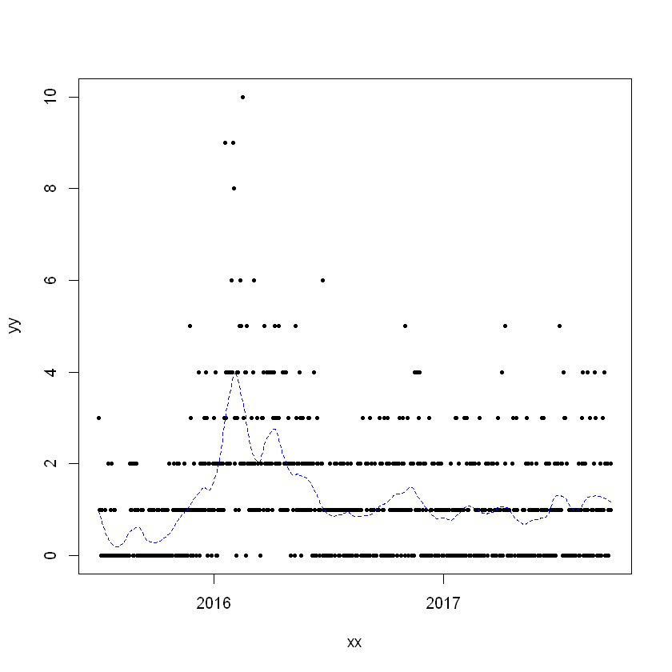

```r
#이마트 노브랜드 감자칩 검색어
boxplot(valid.mat, col='blue')
lines(colMeans(valid.mat), col = "black", lty = 2, lwd = 2)

plot(xx,yy,  pch = 19, cex = 0.5)
points(xx,fit$fitted, type = 'l', lty = 2, lwd = 1.5, col = 'blue')
```

## 6- (2) 검색어 시계열 예측

```
Series: snackts
ARIMA(0,0,0) with non-zero mean

Coefficients:
        mean
      0.0233
s.e.  0.0133

sigma^2 estimated as 0.02289:  log likelihood=61.07
AIC=-118.14   AICc=-118.05   BIC=-112.42
```

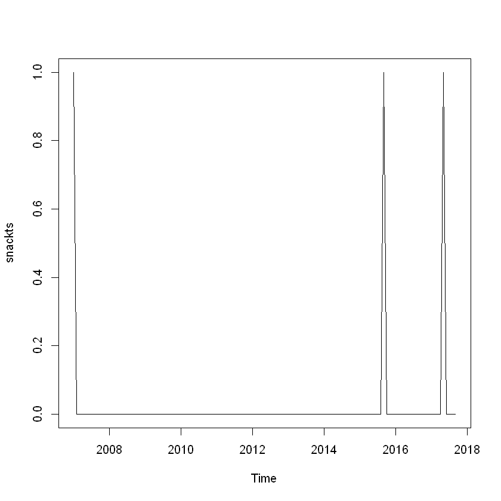

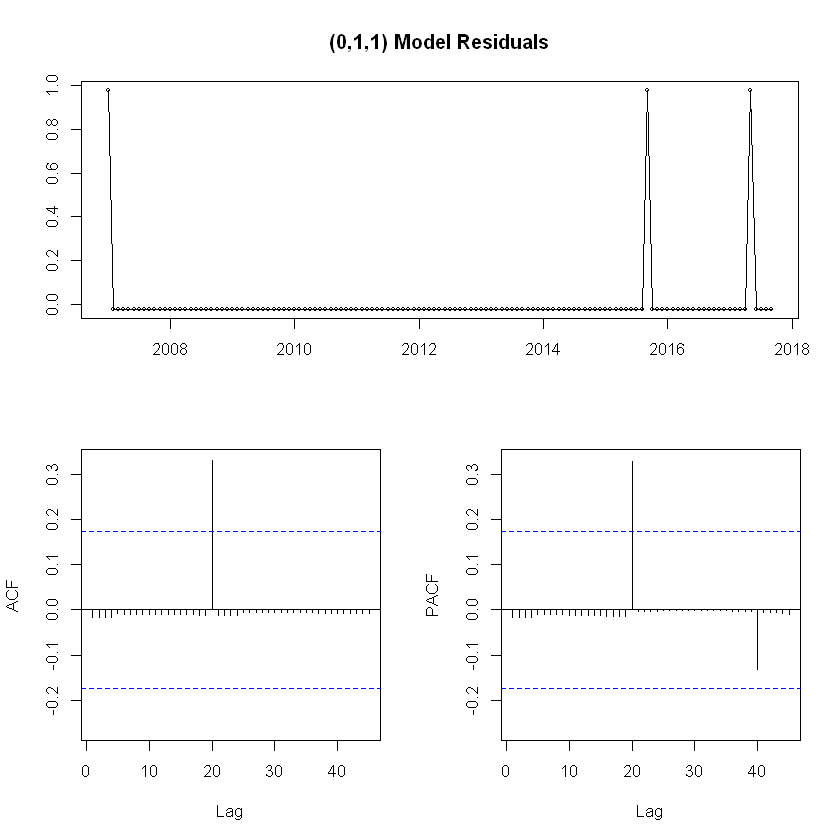

```r
#시계열 자료로 바꾸어 준다.
snackts <- ts(yy, start=c(2007, 1), end=c(2017, 09), frequency=12)
plot(snackts)

#auto.arima 함수를 이용해보자
auto.arima(snackts, seasonal=FALSE)

# 적합시키면서 최적의 값을 찾아보자해보자
fit<-auto.arima(snackts, seasonal=FALSE)
tsdisplay(residuals(fit), lag.max=45, main='(0,1,1) Model Residuals')
```

[figure not shown]

```r
#허니버터칩 시계열 예측
snack_arima <- arima(snackts, order = c(1,1,7))
snack_fcast <- forecast(snack_arima, h = 10)
plot(snack_fcast)
```

```
Series: snackts
ARIMA(1,0,0) with non-zero mean

Coefficients:
         ar1    mean
      0.2713  0.4585
s.e.  0.0899  0.0794

sigma^2 estimated as 0.4405:  log likelihood=-129.2
AIC=264.4   AICc=264.59   BIC=272.98
```

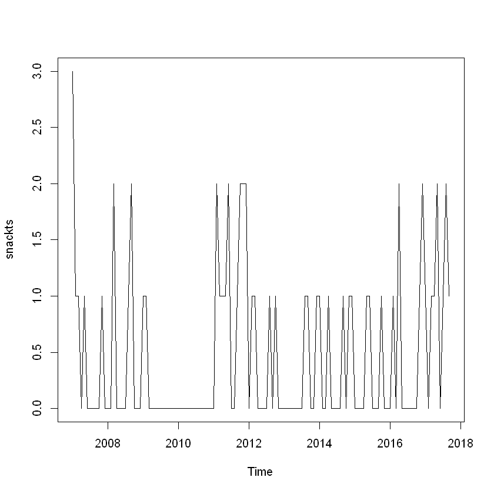

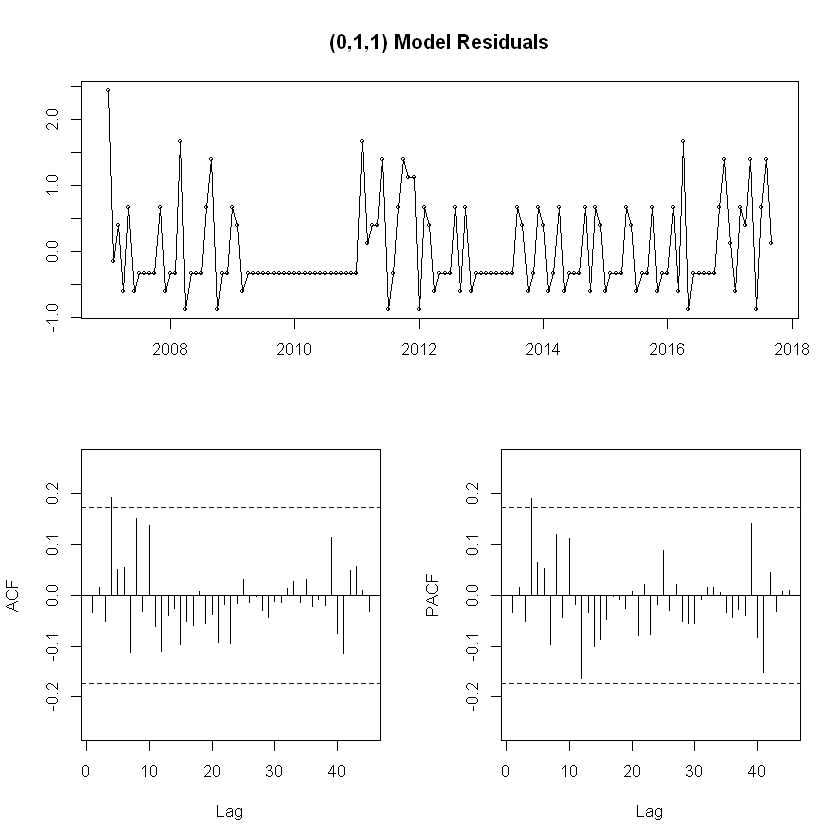

```r
#시계열 자료로 바꾸어 준다.
snackts <- ts(yy, start=c(2007, 1), end=c(2017, 09), frequency=12)
plot(snackts)

#auto.arima 함수를 이용해보자
auto.arima(snackts, seasonal=FALSE)

# 적합시키면서 최적의 값을 찾아보자해보자
fit<-auto.arima(snackts, seasonal=FALSE)
tsdisplay(residuals(fit), lag.max=45, main='(0,1,1) Model Residuals')
```

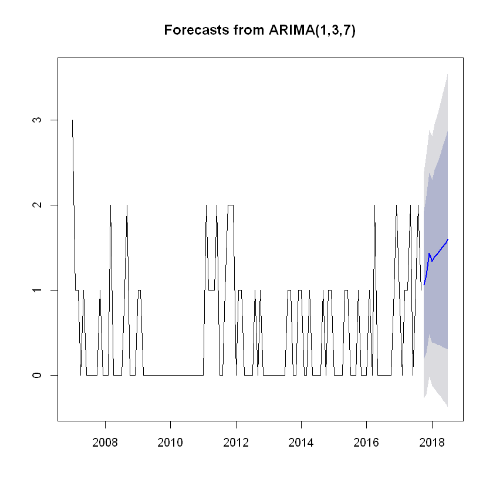

```r
#이마트 노브랜드 감자칩 시계열 예측
snack_arima <- arima(snackts, order = c(1,3,7))
snack_fcast <- forecast(snack_arima, h = 10)
plot(snack_fcast)
```

* 시계열 예측 summary

- 허니버터칩은 검색어가 줄어드는 경향을 보이고, 이마트 노브랜드 감자칩의 검색어가 증가하는 추세를 보인다

# 7. Summary

## ---------------------------------------------------------------------------------------------------------

Summary

- 가장 큰 특징을 보이는 것은 허니버터칩의 '만들기'와 포카칩'맛과 관련된' 단어들이다. 이 두개의 감자칩은 소비자들에게 확실한 브랜드 이미지를 각인 시킨 것으로 보인다.
- 같은 분석 방법을 시도하더라도, 수집된 출처 별로 다른 결과가 나올 것이라 생각했다. 하지만, 비슷한 결과가 나왔다.
- 다양한 분석들을 시도해 보았지만, 분석 방법의 이해가 부족하여 제대로 활용하지 못한 것 같다.
- 네이버 블로그 크롤링에서 description이 아닌 전체 내용을 받을 수 있는 방법을 찾아보았지만, 해결하지 못했다.
- 단어 정제과정도 부족하여, 과자와 관련된 단어들보다 블로그에서 흔히 볼 수 있는 인사말이 많이 나왔다.

## ---------------------------------------------------------------------------------------------------------